# coffee_shop

Author

Faith Hardie

# Coffee Shop Challenge

#### Shop: “Thistle and Kona.”

My coffee shop will offer the Leeward side of Oahu a taste of a culture on the other side of the world, the UK, and mostly Scotland, and combine it with already loved local flavors. From experience and what I see on social media, Sottish, Irish, and English cultures are romanticized, mysticized, and often depicted in fairytale-esque light. Because of this, and the lack of competition for this combination of flavors combined with increased popularity in coffee shops, I believe this venture could succeed. I will use my geo computational skills then, to see if the physical shop could succeed as well, if competition, property, location, etc are taken into account.

### Step 1 - Logo

Every good business needs a name and nice logo, create one manually or with AI for your new cafe and save it as a .png that will show up in your rendered .qmd .html file. (*2 points*)

[figure not shown]

“Thistle & Kona” logo

This Logo was designed with the help of Claude and took inspiration from Island Vintage and Honolulu Coffee co.

### Step 2 - Finding a location

Location: **Halekuai Center at Kapolei,** 563-565 Farrington Hwy, Kapolei, HI 96707

Lat/long: 21.33848629424707, -158.07787057835054

Reason for location: Leeward coast potentially has less coffee-shop competition and cheaper square footage compared to town.

Mapped:

[interactive chart not shown]

### Step 3 - Map the competition

[interactive chart not shown]

There doesn’t seem to be tough competition, there are a few Starbucks locations and a few Coffee Bean and Tea Leaf locations, though. I will note that a few cafes did not make it to this list, such as Island Vintage in Kapolei, only about a mile away from my location.

A few locations popped up that are not explicitly coffee shops too, like Countryside Cafe and Mountain Magic Shave ice.

I included the Waianae range in my map of competition because I know majority of workers in Waianae commute to town or Kapolei regularly, so I did not want to neglect those locations.

In all, there are only 10 unique locations spanning majority of the leeward coast, limiting my competition, and only 7 locations competing in Kapolei.

### Step 4.1 - Resident Customer Demographics

How can we map some spatial information describing your potential customers. Use `tidycensus` to pull in some census data for the tract your coffee shop is in.

Within the get_acs() function think of putting in some of these variable codes based on what is most relevant to your coffee shop (*4 points*)

I have my different variables cleaned and ready to view that I may be interested in. I chose total population, commuters, transit, median rent, and male and female variables, since these may give me a glimpse into the amount of people in my stores chosen location, how many commute, what the rent in the area may be as a gauge for income (?) and female vs male. Now I can map each easily using mapview.

[interactive chart not shown]

Takeaways:

Census Tract 115 is the most populated tract on Oahu in this dataset, with 11,757 residents compared with a median of about 2,800 across the island’s tracts, but I believe this to be an error, unless residents are somehow grouped into this tract. And it also has the most commuters, at 6,123 workers aged 16 and older, which again, may be an error, so I can’t base my results on this. Median gross rent is $2,941, roughly 30% above the island median of $2,198. I read this as a sign of demand for housing in the area, though rent is only an indirect gauge of income. Public transit is a small share of commuting at 3.2 percent, close to the island median of 3.3 percent, so I expect most customers to arrive by car. The tract is 49.8 percent female, essentially even with the island median of 50.2 percent, so the data gives me no reason to target one gender.

### Step 4.2 - Working Customer Demographics

Utilizing [LODES data](https://lehd.ces.census.gov/data/) and the l[ehdr package](https://github.com/jamgreen/lehdr/) make some maps describing workforce characteristics of the tract around your shop (*4 points)*

[interactive chart not shown]

The first pair of maps uses 2022 LODES data to show the jobs located in my tract. Census Tract 115 has 6,402 jobs, which ranks 14th out of 326 tracts, and the median tract only has about 314. This tells me the area is an employment center and not only a place where people live. The pay is also higher than most of the island, with 62 percent of jobs earning more than $3,333 a month compared with a median of 47 percent, and only 14 percent earning $1,250 or less compared with 20 percent. Food service makes up 16 percent of jobs here against a median of 5 percent, and retail makes up 10 percent against 4 percent. I take this as a strong commercial base, though it also means other food businesses are going after the same workers. Workers aged 29 and under are 19.5 percent of jobs, which is the same as the island median, so I don’t see a young workforce skew.

The second pair of maps shows where the workforce comes from and where residents go to work. Only 339 of the 5,414 jobs in the origin-destination data are held by people who also live in the tract, about 6 percent, so most workers are coming in from somewhere else.both flows are useful for the shop because they show a customer base beyond the people who live nearby, which matters since my business is a coffee shop which is in high demand in the mornings.

### Step 5 - What’s nearby?

Utilizing [isochrones](https://walker-data.com/posts/accessibility-surface/) show us whats a 5 minute drive and 10 minute walk from your shop. Think about utilizing rush hour traffic data when people would grab a coffee before work (if that is your audience/customer base) (*4 points)*

[interactive chart not shown]

The isochrone maps show what is reachable from the shop in a short period of time.. SInce a ten minute walk only covers the area around my location, but the drive covers much more, i can assume most customers would arrive by car. Distance traveled during traffic changes fairly noticeably between 7:45 Am and 2pm, so its possible that rush hour traffic may actually decrease my morning reach, but still increase customer base since its a realistic time for peak demand.

### Step 6 - Do you need a generator?

At the county level, use the [eagle i dataset](https://www.osti.gov/biblio/3012826) to show how many times the county your coffee shop is in lost power in 2025. Make a line plot of outages over time with `ggplot` (*3 points*)

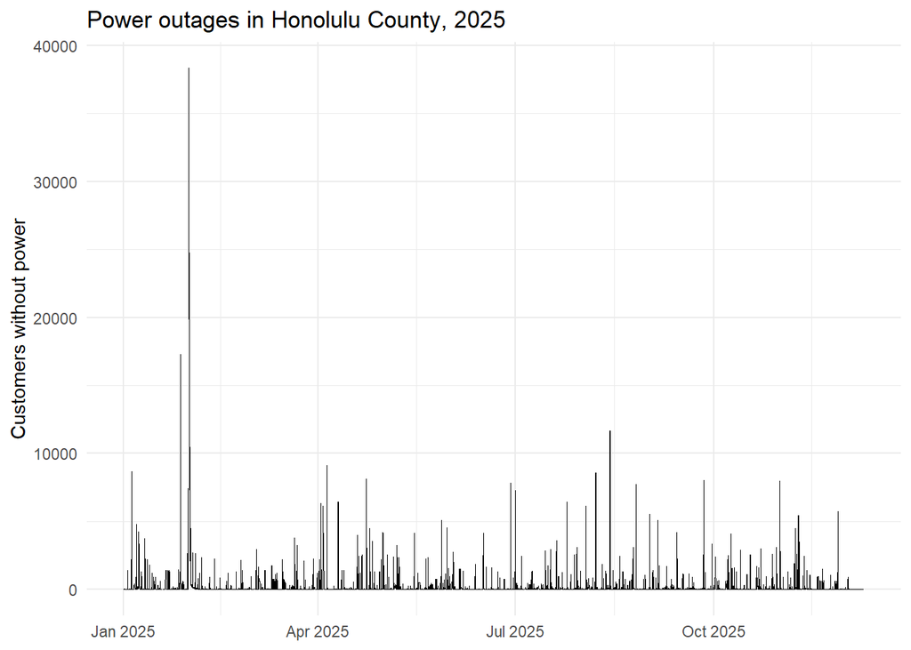

The line plot shows customers without power in Honolulu County at 15-minute intervals through 2025. Most outages stay under about 10,000 customers, but one major event reaches roughly 38,000, and a couple of smaller ones reach 12,000 to 17,000. My cafe depends on refrigeration, espresso machines, and a point-of-sale system, so I think a large outage is a real risk even if it only happens a few times a year. I would plan for a backup power source but I would not treat it as a dealbreaker for the location. The data is countywide, so it does not tell me whether kapolei is hit harder or softer than the rest of the county.

### Step 7 - Conclusion

Conclusion: I think Thistle and Kona at Halekuai Center is a good spot for a coffee shop. The competition is spread across West Oahu instead of packed around my site, so I would not be fighting for the same customers. The ACS estimates make my tract the most populated on Oahu, and median rent is $2,941, maybe 1/3 above island median, which points to steady demand even if the exact population is off. LODES shows around 6,400 jobs in the tract, and over half of them pay over $3,333 a month, so there is a daytime workforce with money to spend. The 5 minute drive at rush hour covers most of Kapolei, including Makakilo and the Villages of Kapolei, while the 10 minute walk only reaches the area around kapolei Regional Park. This means my customers would mostly be people driving in, not walking, but thats commonplace on island and since most people get their coffee commting anyway, I dont see too much of an issue in it, even if its not my ideal. The biggest risk is power, since the outage plot shows one spike of almost 40,000 customers early in 2025 and the shop needs power for the espresso machine and refrigeration. A backup power source would be a smart plan.

Limitations: The ACS and LODES numbers are estimates, the outage data covers all of Honolulu County and not just my tract, and OpenStreetMap may be missing some cafes. Even with those limits, I would open the shop here.